# Downloading and preparing plankton for ISIMIP 3a Baltic mizer

Author

Max Lindmark, following Phoebe.Woodworth-Jefcoats@noaa.gov

Published

2024-02-16

This document describes the workflow for preparing the ISIMIP 3a plankton data for use in the Baltic mizer model. It includes downloading and prepping the plankton data. There are 5 groups of plankton

## Data Access

The first step was accessing the ISIMIP data. I use the code for plankton data in access_levante.txt and run it in the terminal

## Data downloading and wrangling

```r
library(tidyverse); theme_set(theme_light())
library(tidylog)
library(tidync)
library(ncdf4)
library(lubridate)
library(raster)
library(broom)

home <- here::here()

# Read ICES shapefile
shape <- shapefile(paste0(home, "/baltic/FishMIP/ICES-StatRec-mapto-ICES-Areas/StatRec_map_Areas_Full_20170124.shp"))
```

```r
# Read the nc file
# https://stackoverflow.com/questions/76624626/extracting-data-from-netcdf-file-in-r
# library(terra)
# library(tidyterra)
# https://gist.github.com/potterzot/5475ca68d2b5428044a605ce70969ef9

box <- list(lat = c(53, 61), lon = c(12, 32))

## Diatoms
t <- nc_open(paste0(home,
                       "/baltic/FishMIP/Plankton/DataFiles/gfdl-mom6-cobalt2_obsclim_phydiat-vint_15arcmin_global_monthly_1961_2010.nc"))
print(t)
```

```
File /Users/maxlindmark/Dropbox/Max work/R/mizer-rewiring-baltic/baltic/FishMIP/Plankton/DataFiles/gfdl-mom6-cobalt2_obsclim_phydiat-vint_15arcmin_global_monthly_1961_2010.nc (NC_FORMAT_NETCDF4_CLASSIC):

     1 variables (excluding dimension variables):
        float phydiat-vint[lon,lat,time]   (Chunking: [1440,720,1])  (Compression: shuffle,level 5)
            _FillValue: 1.00000002004088e+20
            missing_value: 1.00000002004088e+20
            standard_name: mole_content_of_diatoms_expressed_as_carbon_in_sea_water
            long_name: Mole Content of Diatoms expressed as Carbon in sea water
            units: mol m-2
            comment: vertically integrated over all ocean levels by ISIMIP data management team

     3 dimensions:
        time  Size:600   *** is unlimited ***
            standard_name: time
            long_name: time
            units: months since 1901-1-1 00:00:00
            calendar: 360_day
            axis: T
        lon  Size:1440
            standard_name: longitude
            long_name: longitude
            units: degrees_east
            axis: X
        lat  Size:720
            standard_name: latitude
            long_name: latitude
            units: degrees_north
            axis: Y

    10 global attributes:
        CDI: Climate Data Interface version 1.9.8 (https://mpimet.mpg.de/cdi)
        Conventions: CF-1.6
        filename: 19610101.ocean_cobalt_tracers_month_z.nc
        title: OM4p25_LM3TAN_jra_from1959_init234yrs_dynrivernut_O1756_new
        associated_files: areacello: 19610101.ocean_static.nc
        grid_type: regular
        grid_tile: N/A
        NCO: "4.5.4"
        cdo_openmp_thread_number: 4
        isimip_id: 2413278a-de1e-4380-a837-56bf5addc6c1
```

```r
diatom <- tidync(paste0(home, "/baltic/FishMIP/Plankton/DataFiles/gfdl-mom6-cobalt2_obsclim_phydiat-vint_15arcmin_global_monthly_1961_2010.nc")) %>%
  hyper_filter(
    lat = between(lat, box$lat[[1]], box$lat[[2]]),
    lon = between(lon, box$lon[[1]], box$lon[[2]])
    ) %>% hyper_tibble() %>%
  mutate(date = as.Date("1901-01-01") %m+% months(time)) %>%
  dplyr::select(-c(time))
```

```
mutate: new variable 'date' (Date) with 600 unique values and 0% NA
```

```r
# Add in ICES areas so that we can filter the domain of the mizer model
pts <- SpatialPoints(cbind(diatom$lon, diatom$lat),
                     proj4string = CRS(proj4string(shape)))

diatom$sub_div <- over(pts, shape)$Area_27

diatom <- diatom %>%
  filter(sub_div %in% c("3.d.25", "3.d.26", "3.d.27", "3.d.28.1", "3.d.28.2", "3.d.29", "3.d.32")) %>%
  mutate(sub_div = as.factor(sub_div)) %>%
  droplevels() %>%
  mutate(sub_div = fct_recode(sub_div,
                              "25" = "3.d.25",
                              "26" = "3.d.26",
                              "27" = "3.d.27",
                              "28" = "3.d.28.1",
                              "28" = "3.d.28.2",
                              "29" = "3.d.29",
                              "32" = "3.d.32"))
```

```
filter: removed 46,200 rows (13%), 303,600 rows remaining
```

```
mutate: converted 'sub_div' from character to factor (0 new NA)
```

```
mutate: changed 303,600 values (100%) of 'sub_div' (0 new NA)
```

```r
## Diazotrophs
t <- nc_open(paste0(home,
                       "/baltic/FishMIP/Plankton/DataFiles/gfdl-mom6-cobalt2_obsclim_phydiaz-vint_15arcmin_global_monthly_1961_2010.nc"))
print(t)
```

```
File /Users/maxlindmark/Dropbox/Max work/R/mizer-rewiring-baltic/baltic/FishMIP/Plankton/DataFiles/gfdl-mom6-cobalt2_obsclim_phydiaz-vint_15arcmin_global_monthly_1961_2010.nc (NC_FORMAT_NETCDF4_CLASSIC):

     1 variables (excluding dimension variables):
        float phydiaz-vint[lon,lat,time]   (Chunking: [1440,720,1])  (Compression: shuffle,level 5)
            _FillValue: 1.00000002004088e+20
            missing_value: 1.00000002004088e+20
            standard_name: mole_content_of_diazotrophs_expressed_as_carbon_in_sea_water
            long_name: Mole Content of Diazotrophs expressed as Carbon in sea water
            units: mol m-2
            comment: vertically integrated over all ocean levels by ISIMIP data management team

     3 dimensions:
        time  Size:600   *** is unlimited ***
            standard_name: time
            long_name: time
            units: months since 1901-1-1 00:00:00
            calendar: 360_day
            axis: T
        lon  Size:1440
            standard_name: longitude
            long_name: longitude
            units: degrees_east
            axis: X
        lat  Size:720
            standard_name: latitude
            long_name: latitude
            units: degrees_north
            axis: Y

    10 global attributes:
        CDI: Climate Data Interface version 1.9.8 (https://mpimet.mpg.de/cdi)
        Conventions: CF-1.6
        filename: 19610101.ocean_cobalt_tracers_month_z.nc
        title: OM4p25_LM3TAN_jra_from1959_init234yrs_dynrivernut_O1756_new
        associated_files: areacello: 19610101.ocean_static.nc
        grid_type: regular
        grid_tile: N/A
        NCO: "4.5.4"
        cdo_openmp_thread_number: 4
        isimip_id: 020386f3-68e7-4587-a969-8c468dc7b04f
```

```r
diaz <- tidync(paste0(home, "/baltic/FishMIP/Plankton/DataFiles/gfdl-mom6-cobalt2_obsclim_phydiaz-vint_15arcmin_global_monthly_1961_2010.nc")) %>%
  hyper_filter(
    lat = between(lat, box$lat[[1]], box$lat[[2]]),
    lon = between(lon, box$lon[[1]], box$lon[[2]])
    ) %>% hyper_tibble() %>%
  mutate(date = as.Date("1901-01-01") %m+% months(time)) %>%
  dplyr::select(-c(time))
```

```
mutate: new variable 'date' (Date) with 600 unique values and 0% NA
```

```r
# Add in ICES areas so that we can filter the domain of the mizer model
pts <- SpatialPoints(cbind(diaz$lon, diaz$lat),
                     proj4string = CRS(proj4string(shape)))

diaz$sub_div <- over(pts, shape)$Area_27

diaz <- diaz %>%
  filter(sub_div %in% c("3.d.25", "3.d.26", "3.d.27", "3.d.28.1", "3.d.28.2", "3.d.29", "3.d.32")) %>%
  mutate(sub_div = as.factor(sub_div)) %>%
  droplevels() %>%
  mutate(sub_div = fct_recode(sub_div,
                              "25" = "3.d.25",
                              "26" = "3.d.26",
                              "27" = "3.d.27",
                              "28" = "3.d.28.1",
                              "28" = "3.d.28.2",
                              "29" = "3.d.29",
                              "32" = "3.d.32"))
```

```
filter: removed 46,200 rows (13%), 303,600 rows remaining
```

```
mutate: converted 'sub_div' from character to factor (0 new NA)
```

```
mutate: changed 303,600 values (100%) of 'sub_div' (0 new NA)
```

```r
## Picophytoplankton
t <- nc_open(paste0(home,
                       "/baltic/FishMIP/Plankton/DataFiles/gfdl-mom6-cobalt2_obsclim_phypico-vint_15arcmin_global_monthly_1961_2010.nc"))
print(t)
```

```
File /Users/maxlindmark/Dropbox/Max work/R/mizer-rewiring-baltic/baltic/FishMIP/Plankton/DataFiles/gfdl-mom6-cobalt2_obsclim_phypico-vint_15arcmin_global_monthly_1961_2010.nc (NC_FORMAT_NETCDF4_CLASSIC):

     1 variables (excluding dimension variables):
        float phypico-vint[lon,lat,time]   (Chunking: [1440,720,1])  (Compression: shuffle,level 5)
            _FillValue: 1.00000002004088e+20
            missing_value: 1.00000002004088e+20
            standard_name: mole_content_of_picophytoplankton_expressed_as_carbon_in_sea_water
            long_name: Mole Content of Picophytoplankton expressed as Carbon in sea water
            units: mol m-2
            comment: vertically integrated over all ocean levels by ISIMIP data management team

     3 dimensions:
        time  Size:600   *** is unlimited ***
            standard_name: time
            long_name: time
            units: months since 1901-1-1 00:00:00
            calendar: 360_day
            axis: T
        lon  Size:1440
            standard_name: longitude
            long_name: longitude
            units: degrees_east
            axis: X
        lat  Size:720
            standard_name: latitude
            long_name: latitude
            units: degrees_north
            axis: Y

    10 global attributes:
        CDI: Climate Data Interface version 1.9.8 (https://mpimet.mpg.de/cdi)
        Conventions: CF-1.6
        filename: 19610101.ocean_cobalt_tracers_month_z.nc
        title: OM4p25_LM3TAN_jra_from1959_init234yrs_dynrivernut_O1756_new
        associated_files: areacello: 19610101.ocean_static.nc
        grid_type: regular
        grid_tile: N/A
        NCO: "4.5.4"
        cdo_openmp_thread_number: 4
        isimip_id: 34ae27e6-649e-454c-953b-3e89eae28449
```

```r
pico <- tidync(paste0(home, "/baltic/FishMIP/Plankton/DataFiles/gfdl-mom6-cobalt2_obsclim_phypico-vint_15arcmin_global_monthly_1961_2010.nc")) %>%
  hyper_filter(
    lat = between(lat, box$lat[[1]], box$lat[[2]]),
    lon = between(lon, box$lon[[1]], box$lon[[2]])
    ) %>% hyper_tibble() %>%
  mutate(date = as.Date("1901-01-01") %m+% months(time)) %>%
  dplyr::select(-c(time))
```

```
mutate: new variable 'date' (Date) with 600 unique values and 0% NA
```

```r
# Add in ICES areas so that we can filter the domain of the mizer model
pts <- SpatialPoints(cbind(pico$lon, pico$lat),
                     proj4string = CRS(proj4string(shape)))

pico$sub_div <- over(pts, shape)$Area_27

pico <- pico %>%
  filter(sub_div %in% c("3.d.25", "3.d.26", "3.d.27", "3.d.28.1", "3.d.28.2", "3.d.29", "3.d.32")) %>%
  mutate(sub_div = as.factor(sub_div)) %>%
  droplevels() %>%
  mutate(sub_div = fct_recode(sub_div,
                              "25" = "3.d.25",
                              "26" = "3.d.26",
                              "27" = "3.d.27",
                              "28" = "3.d.28.1",
                              "28" = "3.d.28.2",
                              "29" = "3.d.29",
                              "32" = "3.d.32"))
```

```
filter: removed 46,200 rows (13%), 303,600 rows remaining
```

```
mutate: converted 'sub_div' from character to factor (0 new NA)
```

```
mutate: changed 303,600 values (100%) of 'sub_div' (0 new NA)
```

```r
## Mesozooplankton
t <- nc_open(paste0(home,
                       "/baltic/FishMIP/Plankton/DataFiles/gfdl-mom6-cobalt2_obsclim_zmeso-vint_15arcmin_global_monthly_1961_2010.nc"))
print(t)
```

```
File /Users/maxlindmark/Dropbox/Max work/R/mizer-rewiring-baltic/baltic/FishMIP/Plankton/DataFiles/gfdl-mom6-cobalt2_obsclim_zmeso-vint_15arcmin_global_monthly_1961_2010.nc (NC_FORMAT_NETCDF4_CLASSIC):

     1 variables (excluding dimension variables):
        float zmeso-vint[lon,lat,time]   (Chunking: [1440,720,1])  (Compression: shuffle,level 5)
            _FillValue: 1.00000002004088e+20
            missing_value: 1.00000002004088e+20
            standard_name: mole_content_of_mesoplankton_expressed_as_carbon_in_sea_water
            long_name: Mesozooplankton Carbon Content
            units: mol m-2
            comment: vertically integrated of upper 100m ocean levels by ISIMIP data management team

     3 dimensions:
        time  Size:600   *** is unlimited ***
            standard_name: time
            long_name: time
            units: months since 1901-1-1 00:00:00
            calendar: 360_day
            axis: T
        lon  Size:1440
            standard_name: longitude
            long_name: longitude
            units: degrees_east
            axis: X
        lat  Size:720
            standard_name: latitude
            long_name: latitude
            units: degrees_north
            axis: Y

    10 global attributes:
        CDI: Climate Data Interface version 1.9.8 (https://mpimet.mpg.de/cdi)
        Conventions: CF-1.6
        filename: 19610101.ocean_cobalt_tracers_month_z.nc
        title: OM4p25_LM3TAN_jra_from1959_init234yrs_dynrivernut_O1756_new
        associated_files: areacello: 19610101.ocean_static.nc
        grid_type: regular
        grid_tile: N/A
        NCO: netCDF Operators version 4.8.1 (Homepage = http://nco.sf.net, Code = http://github.com/nco/nco)
        cdo_openmp_thread_number: 4
        isimip_id: fa2fc508-4a3b-483b-9090-0743e7b35818
```

```r
meso <- tidync(paste0(home, "/baltic/FishMIP/Plankton/DataFiles/gfdl-mom6-cobalt2_obsclim_zmeso-vint_15arcmin_global_monthly_1961_2010.nc")) %>%
  hyper_filter(
    lat = between(lat, box$lat[[1]], box$lat[[2]]),
    lon = between(lon, box$lon[[1]], box$lon[[2]])
    ) %>% hyper_tibble() %>%
  mutate(date = as.Date("1901-01-01") %m+% months(time)) %>%
  dplyr::select(-c(time))
```

```
mutate: new variable 'date' (Date) with 600 unique values and 0% NA
```

```r
# Add in ICES areas so that we can filter the domain of the mizer model
pts <- SpatialPoints(cbind(meso$lon, meso$lat),
                     proj4string = CRS(proj4string(shape)))

meso$sub_div <- over(pts, shape)$Area_27

meso <- meso %>%
  filter(sub_div %in% c("3.d.25", "3.d.26", "3.d.27", "3.d.28.1", "3.d.28.2", "3.d.29", "3.d.32")) %>%
  mutate(sub_div = as.factor(sub_div)) %>%
  droplevels() %>%
  mutate(sub_div = fct_recode(sub_div,
                              "25" = "3.d.25",
                              "26" = "3.d.26",
                              "27" = "3.d.27",
                              "28" = "3.d.28.1",
                              "28" = "3.d.28.2",
                              "29" = "3.d.29",
                              "32" = "3.d.32"))
```

```
filter: removed 46,200 rows (13%), 303,600 rows remaining
```

```
mutate: converted 'sub_div' from character to factor (0 new NA)
```

```
mutate: changed 303,600 values (100%) of 'sub_div' (0 new NA)
```

```r
## Microzooplankton
t <- nc_open(paste0(home,
                       "/baltic/FishMIP/Plankton/DataFiles/gfdl-mom6-cobalt2_obsclim_zmicro-vint_15arcmin_global_monthly_1961_2010.nc"))
print(t)
```

```
File /Users/maxlindmark/Dropbox/Max work/R/mizer-rewiring-baltic/baltic/FishMIP/Plankton/DataFiles/gfdl-mom6-cobalt2_obsclim_zmicro-vint_15arcmin_global_monthly_1961_2010.nc (NC_FORMAT_NETCDF4_CLASSIC):

     1 variables (excluding dimension variables):
        float zmicro-vint[lon,lat,time]   (Chunking: [1440,720,1])  (Compression: shuffle,level 5)
            _FillValue: 1.00000002004088e+20
            missing_value: 1.00000002004088e+20
            standard_name: mole_content_of_microplankton_expressed_as_carbon_in_sea_water
            long_name: Microzooplankton Carbon Content
            units: mol m-2
            comment: vertically integrated of upper 100m ocean levels by ISIMIP data management team

     3 dimensions:
        time  Size:600   *** is unlimited ***
            standard_name: time
            long_name: time
            units: months since 1901-1-1 00:00:00
            calendar: 360_day
            axis: T
        lon  Size:1440
            standard_name: longitude
            long_name: longitude
            units: degrees_east
            axis: X
        lat  Size:720
            standard_name: latitude
            long_name: latitude
            units: degrees_north
            axis: Y

    10 global attributes:
        CDI: Climate Data Interface version 1.9.8 (https://mpimet.mpg.de/cdi)
        Conventions: CF-1.6
        filename: 19610101.ocean_cobalt_tracers_month_z.nc
        title: OM4p25_LM3TAN_jra_from1959_init234yrs_dynrivernut_O1756_new
        associated_files: areacello: 19610101.ocean_static.nc
        grid_type: regular
        grid_tile: N/A
        NCO: "4.5.4"
        cdo_openmp_thread_number: 4
        isimip_id: cc568627-6a32-491f-90b2-49d2d57d2125
```

```r
micro <- tidync(paste0(home, "/baltic/FishMIP/Plankton/DataFiles/gfdl-mom6-cobalt2_obsclim_zmicro-vint_15arcmin_global_monthly_1961_2010.nc")) %>%
  hyper_filter(
    lat = between(lat, box$lat[[1]], box$lat[[2]]),
    lon = between(lon, box$lon[[1]], box$lon[[2]])
    ) %>% hyper_tibble() %>%
  mutate(date = as.Date("1901-01-01") %m+% months(time)) %>%
  dplyr::select(-c(time))
```

```
mutate: new variable 'date' (Date) with 600 unique values and 0% NA
```

```r
# Add in ICES areas so that we can filter the domain of the mizer model
pts <- SpatialPoints(cbind(micro$lon, micro$lat),
                     proj4string = CRS(proj4string(shape)))

micro$sub_div <- over(pts, shape)$Area_27

micro <- micro %>%
  filter(sub_div %in% c("3.d.25", "3.d.26", "3.d.27", "3.d.28.1", "3.d.28.2", "3.d.29", "3.d.32")) %>%
  mutate(sub_div = as.factor(sub_div)) %>%
  droplevels() %>%
  mutate(sub_div = fct_recode(sub_div,
                              "25" = "3.d.25",
                              "26" = "3.d.26",
                              "27" = "3.d.27",
                              "28" = "3.d.28.1",
                              "28" = "3.d.28.2",
                              "29" = "3.d.29",
                              "32" = "3.d.32"))
```

```
filter: removed 46,200 rows (13%), 303,600 rows remaining
```

```
mutate: converted 'sub_div' from character to factor (0 new NA)
```

```
mutate: changed 303,600 values (100%) of 'sub_div' (0 new NA)
```

```r
# Combine all into a dataframe
pl <- bind_rows(diatom %>% rename(mole_content = `phydiat-vint`) %>% mutate(type = "diatom"),
                diaz %>% rename(mole_content = `phydiaz-vint`) %>% mutate(type = "diazotrophs"),
                pico %>% rename(mole_content = `phypico-vint`) %>% mutate(type = "phypico"),
                meso %>% rename(mole_content = `zmeso-vint`) %>% mutate(type = "mesozp"),
                micro %>% rename(mole_content = `zmicro-vint`) %>% mutate(type = "microzp"))
```

```
rename: renamed one variable (mole_content)
```

```
mutate: new variable 'type' (character) with one unique value and 0% NA
```

```
rename: renamed one variable (mole_content)
```

```
mutate: new variable 'type' (character) with one unique value and 0% NA
```

```
rename: renamed one variable (mole_content)
```

```
mutate: new variable 'type' (character) with one unique value and 0% NA
```

```
rename: renamed one variable (mole_content)
```

```
mutate: new variable 'type' (character) with one unique value and 0% NA
```

```
rename: renamed one variable (mole_content)
```

```
mutate: new variable 'type' (character) with one unique value and 0% NA
```

```r
# Do the same conversions that Phoebe does in the script Plankton_ts.jnl
# ! We want total carbon in g, so we'll need to:
# ! Convert from mol C to g C (*12.011)
# ! Convert area from km^2 to m^2 (*10^6)
# ! Sum

pl$g_C <- pl$mole_content*12.011

# TODO: check if this is correct. The nc files are in units: mol m-2, so we convert from k^m to m^2??
# I think I need to convert to my area, right? 2.49×10^11 m^2
# But how can I do that without knowing the area of each "grid cell" the point represents?
# Do I sum across spatial points and then just... multiply by areal extent?
# But if it's in unit per m2, then I ought to take an average...

pl_sum <- pl %>%
  summarise(g_C = sum(g_C), .by = c(date, type)) %>%
  mutate(sum_g_C = g_C*2.49e+11)
```

```
summarise: now 3,000 rows and 3 columns, ungrouped
```

```
mutate: new variable 'sum_g_C' (double) with 3,000 unique values and 0% NA
```

Convert the units to get information about the intercept and slope of the resource size-spectra. This is following Phoebe’s code Prep_Plankton_therMizer.Rmd, which reads in data prepared in Plankton_ts.jnl, which reads in the nc files and “plankton carbon densities were converted to total carbon and summed over the model domain”. Now we need to make further conversions.

Here, this total carbon is used to create resource spectra at each time step.

Size class ranges, for reference (ESD = Equivalent Spherical Diameter):  
- Phyto = 0.2 - 200 um ESD (mid-point size = 100.1 um ESD)  
- pico = 0.2 - 10 um ESD (mid-point size = 5.1 um ESD)  
- large (diatoms and diazotrophs) = 10 - 200 um ESD (mid-point size = 105 um ESD)  
- Zoo = 2 - 20,00 um ESD (based on the literature)(mid-point size = 10001 um ESD)  
- zmicro = 2 - 200 um ESD (mid-point size = 101 um ESD)  
- zmeso = 200 - 20000 um ESD (mid-point size = 10100 um ESD)

These size classes were informed by Dunne et al. [2005](https://doi.org/10.1029/2004GB002390), [2012](https://doi.org/10.1029/2010GB003935), and [2013](https://doi.org/10.1175/JCLI-D-12-00150.1), [Liu et al. 2021](https://doi.org/10.1029/2021GL094367), and [Stock et al. 2020](https://doi.org/10.1029/2019MS002043).

Conversions used:  
- Convert g C to gww –> $\times 10$  
- Convert um ESD to gww –> $\frac{4}{3}\pi(0.5\times0.0001\times size)^3$

```r
# Create variables for referencing the size class mid points, in gww
pico_mid <- (4/3)*pi*((0.5*0.0001*5.1)^3)
large_mid <- (4/3)*pi*((0.5*0.0001*105)^3)
micro_mid <- (4/3)*pi*((0.5*0.0001*101)^3)
meso_mid <- (4/3)*pi*((0.5*0.0001*10100)^3)

mid_df <- data.frame(type = c("diatom",  "diazotrophs", "phypico", "mesozp", "microzp"),
                     midpoint = c(large_mid, large_mid,     pico_mid,  pico_mid, micro_mid))

# Convert total carbon to gww and then get numerical abundance by dividing by size class mid point
# This step assumes that all plankton are the midpoint size
pl <- pl %>%
  left_join(mid_df, by = "type") %>%
  mutate(abund = g_C*10/midpoint) # TODO: Pheobes g_C is scaled by to km^2, mine only converted to carbon
```

```
left_join: added one column (midpoint)
```

```
           > rows only in x           0
```

```
           > rows only in y  (        0)
```

```
           > matched rows     1,518,000
```

```
           >                 ===========
```

```
           > rows total       1,518,000
```

```
mutate: new variable 'abund' (double) with 1,508,870 unique values and 0% NA
```

```r
# TODO: I don't need spatial data to estimate the intercept and slope, but at this point I'm not sure how to sum, so I calculate the mean in the spatial domain.
pl_fit <- pl %>%
  summarise(mean_abund = mean(abund), .by = c(date, type)) %>%
  left_join(mid_df)
```

```
summarise: now 3,000 rows and 3 columns, ungrouped
```

```
left_join: added one column (midpoint)
> rows only in x 0
> rows only in y ( 0)
> matched rows 3,000
> =======
> rows total 3,000
```

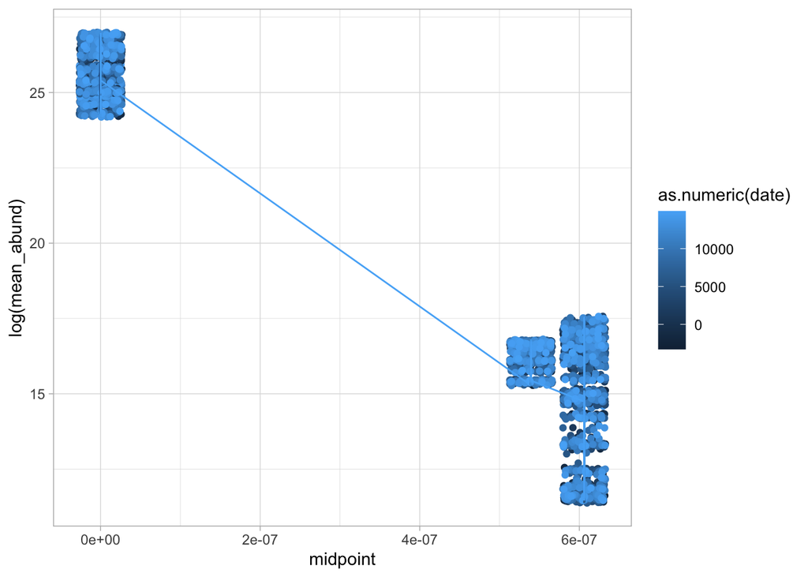

```r
ggplot(pl_fit, aes(midpoint, log(mean_abund), color = as.numeric(date))) +
  geom_jitter() +
  geom_line()
```

```r
# Fit a model to estimate the slope and intercept for all time steps
m <- lm(log10(mean_abund) ~ 0 + log10(midpoint)*as.factor(date), data = pl_fit)

# Main effect of log(midpoint)
main_slope <- tidy(m) %>%
  filter(term == "log10(midpoint)") %>%
  distinct(estimate)
```

```
filter: removed 1,199 rows (>99%), one row remaining
distinct: no rows removed
```

```r
# Extract the slopes at each time step
slopes <- tidy(m) %>%
  filter(grepl("log10", term)) %>%
  filter(!term == "log10(midpoint)") %>%
  mutate(slope = estimate + main_slope$estimate) %>%
  separate(term, into = c("term", "date"), ":") %>%
  mutate(date = str_replace(date, "as.factor", "")) %>%
  mutate(date = str_replace(date, "(date)", "")) %>%
  mutate(date = str_replace(date, "[()]", "")) %>%
  mutate(date = str_replace(date, "[()]", "")) %>%
  mutate(year = year(as.Date(date))) %>%
  dplyr::select(term, year, date, slope) %>%
  rename(estimate = slope) %>%
  mutate(term = "slope")
```

```
filter: removed 600 rows (50%), 600 rows remaining
filter: removed one row (<1%), 599 rows remaining
mutate: new variable 'slope' (double) with 599 unique values and 0% NA
mutate: changed 599 values (100%) of 'date' (0 new NA)
mutate: changed 599 values (100%) of 'date' (0 new NA)
mutate: changed 599 values (100%) of 'date' (0 new NA)
mutate: changed 599 values (100%) of 'date' (0 new NA)
mutate: new variable 'year' (double) with 50 unique values and 0% NA
rename: renamed one variable (estimate)
mutate: changed 599 values (100%) of 'term' (0 new NA)
```

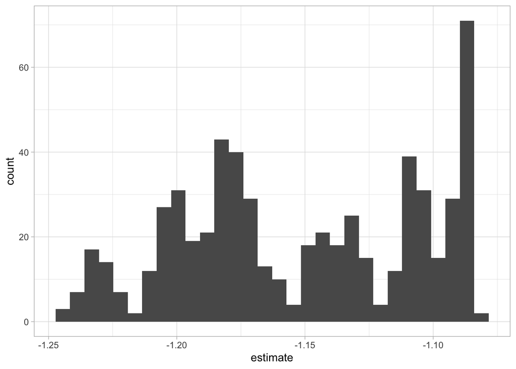

```r
ggplot(slopes, aes(estimate)) +
  geom_histogram()
```

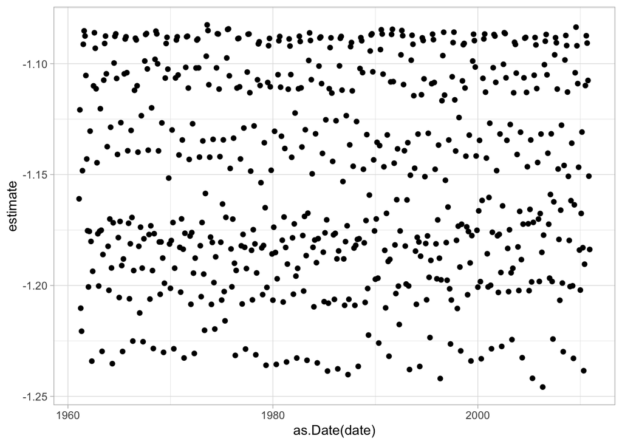

```r
ggplot(slopes, aes(as.Date(date), estimate)) +
  geom_point()
```

```
filter: removed 372 rows (62%), 227 rows remaining
```

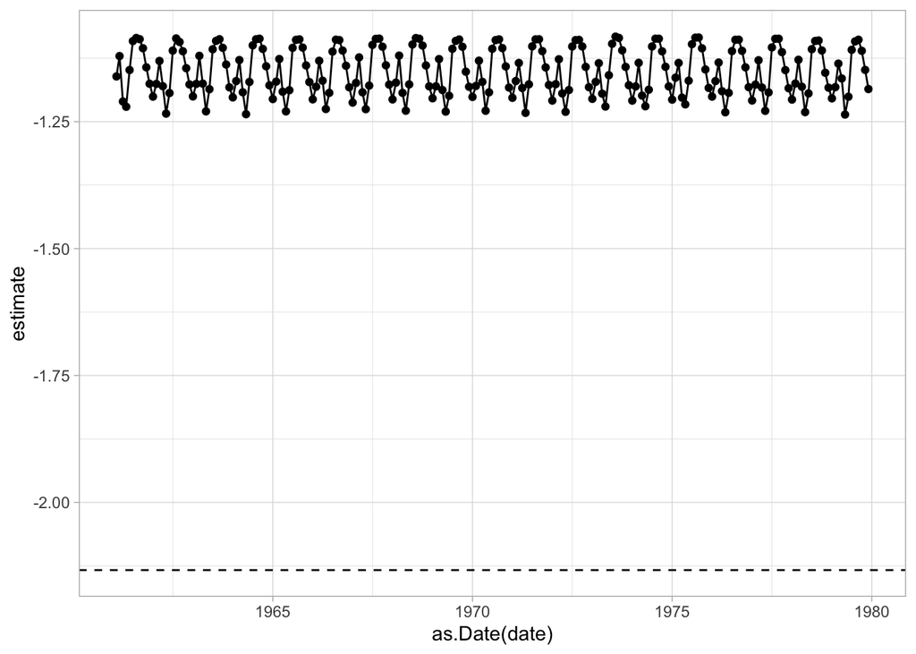

```r
slopes %>%
  filter(year < 1980) %>%
  ggplot(aes(as.Date(date), estimate)) +
  geom_point() +
  geom_line() +
  geom_hline(yintercept = -2-0.8+(2/3), linetype = 2)
```

```r
# Very cyclical! And also... the value is quite different from the size-spectrum slope I currently have,

# Now get the intercepts
inter <- tidy(m) %>%
  filter(!grepl(":", term)) %>%
  filter(!term == "log10(midpoint)") %>%
  separate(term, into = c("term", "date"), "[)]") %>%
  mutate(term = "intercept",
         year = year(as.Date(date))) %>%
  dplyr::select(term, year, date, estimate) %>%
  mutate(estimate = 10^estimate)
```

```
filter: removed 599 rows (50%), 601 rows remaining
filter: removed one row (<1%), 600 rows remaining
mutate: changed 600 values (100%) of 'term' (0 new NA)
        new variable 'year' (double) with 50 unique values and 0% NA
mutate: changed 600 values (100%) of 'estimate' (0 new NA)
```

```r
coefs <- bind_rows(inter, slopes) %>%
  mutate(month = month(as.Date(date)))
```

```
mutate: new variable 'month' (double) with 12 unique values and 0% NA
```

```r
# Add the scaled estimates...
coefs <- coefs %>%
  group_by(term) %>%
  mutate(estimate_sc = estimate / mean(estimate)) %>%
  ungroup()
```

```
group_by: one grouping variable (term)
mutate (grouped): new variable 'estimate_sc' (double) with 1,199 unique values and 0% NA
ungroup: no grouping variables
```

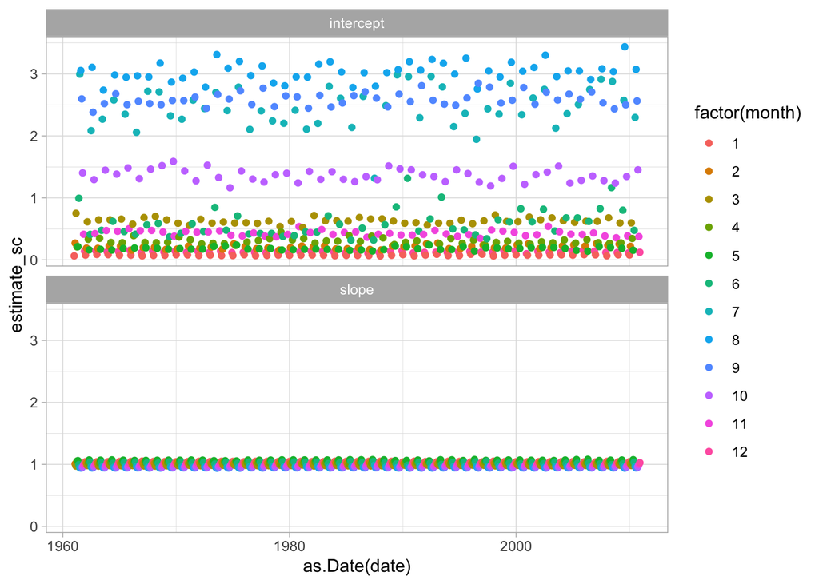

```r
ggplot(coefs, aes(as.Date(date), estimate_sc, color = factor(month))) +
  geom_point() +
  facet_wrap(~term, ncol = 1)
```

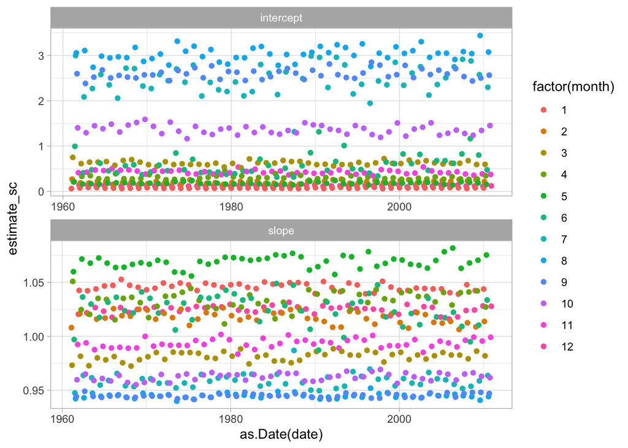

```r
ggplot(coefs, aes(as.Date(date), estimate_sc, color = factor(month))) +
  geom_point() +
  facet_wrap(~term, ncol = 1, scales = "free")
```

```r
# Huge difference between months... perhaps I need to aggregate?
coefs <- coefs %>%
  group_by(term, year) %>%
  mutate(estimate_agg = mean(estimate)) %>%
  group_by(term) %>%
  mutate(estimate_agg_sc = estimate_agg / mean(estimate_agg)) %>%
  ungroup()
```

```
group_by: 2 grouping variables (term, year)
mutate (grouped): new variable 'estimate_agg' (double) with 100 unique values and 0% NA
group_by: one grouping variable (term)
mutate (grouped): new variable 'estimate_agg_sc' (double) with 100 unique values and 0% NA
ungroup: no grouping variables
```

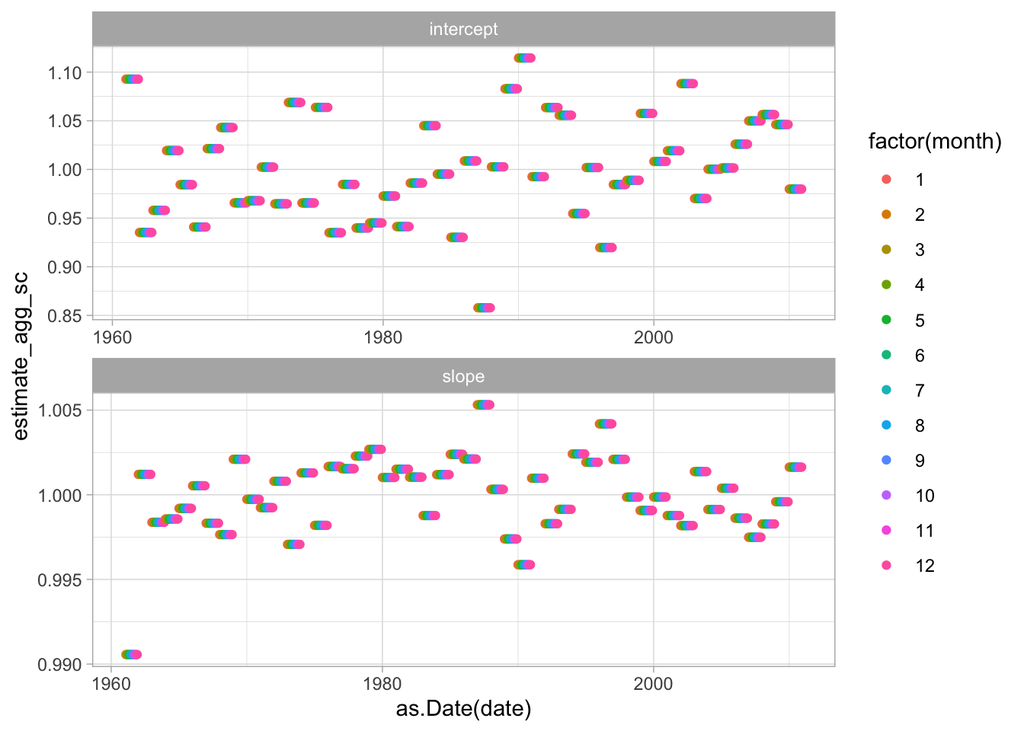

```r
ggplot(coefs, aes(as.Date(date), estimate_agg_sc, color = factor(month))) +
  geom_point() +
  facet_wrap(~term, ncol = 1, scales = "free")
```

Save

```r
coefs_save <- coefs

write_csv(coefs_save, paste0(home, "/baltic/FishMIP/Input-mizer/resource_df.csv"))
```